# Assignment 1 2020

Bin Kim

Under Modules | Data | Bikes on Canvas you have data on the number of people counted cycling in Auckland and the amount of rain.

Initial data preparation

```r
bike_files = list.files(".", "*.csv", full=TRUE)
bike_data = map(bike_files, read_csv)
notallNA = function(x) !all(is.na(x))
bike_data = map(bike_data, select_if, notallNA)

bike_data = map(bike_data, pivot_longer, -Date, names_to = "Counter_Spot", values_to = "Count")
bike_data = bind_rows(bike_data)

# Change the `Date` column type from chr to date.
bike_data$Date = as.Date(bike_data$Date, format="%a %d %b %Y")
```

# 1. If you try to convert the cycle count data to tidy format (which you don't have to do for this assignment, because it's hard), what is one obstacle you will encounter?

```r
bike_data %>%
    group_by(Counter_Spot) %>%
    summarise(n())
```

```
## # A tibble: 63 x 2
##    Counter_Spot                                `n()`
##    <chr>                                       <int>
##  1 Archibald Park Cyclists                       366
##  2 Beach Road Cyclists                          1097
##  3 Carlton Gore Cycle Counter Cyclists          1097
##  4 Curran St total                               366
##  5 Curran Street Total                           365
##  6 Curran Street Total Cyclists                  366
##  7 Dominion Road (near View Rd) Total Cyclists   365
##  8 Dominion Road Total Cyclists                  366
##  9 East Coast Road Cyclists                      366
## 10 East_Coast_Road Cyclists                      731
## # … with 53 more rows
```

Tidydata consists of unique observations only. We can tell from the table above that, for some streets, the 3 initial datasets of different years each had different naming (e.g. `Curran St total`, `Curran Street Total`, `Curran Street Total Cyclists`), and this violates the tidyverse's unique observation rule. It is hard to merge them together because although humans can easily detect such naming errors, it is not the case for the computers. Merge process would require laborious human interference of renaming each overlapping `Counter_Spot` and creating new variable for the new names (as we did in Lab 2).

# 2. Compute the total number of cyclists counted for each day, and a suitable summary of the rainfall for each day, in the same data frame.

```r
## First, summarise total cyclist info
bike_sum_day <- bike_data %>%
    group_by(Date) %>%
    summarise(`bike_count/day`=sum(Count, na.rm = TRUE))
bike_sum_day
```

```
## # A tibble: 1,097 x 2
##    Date       `bike_count/day`
##    <date>                <dbl>
##  1 2016-01-01             1299
##  2 2016-01-02             1030
##  3 2016-01-03             7423
##  4 2016-01-04            11956
##  5 2016-01-05            10167
##  6 2016-01-06            10387
##  7 2016-01-07             9573
##  8 2016-01-08             3535
##  9 2016-01-09             8998
## 10 2016-01-10            10429
## # … with 1,087 more rows
```

```r
## Second, summarise the rain info
rain_files = list.files(".", "*.txt", full=TRUE)
rain_data = map(rain_files, read_delim, skip=9, delim=",") # I hand-deleted the last few descriptive lines of the files.
# Deleting the last 2 rows of the 2016-2017 data because they are 2018 data.
rain_data[[1]] = rain_data[[1]][-c(nrow(rain_data[[1]]), nrow(rain_data[[1]])-1), ]
tail(rain_data[[1]])
```

```
## # A tibble: 6 x 6
##   Station `Date(NZST)` `Time(NZST)` `Amount(mm)` `Period(Hrs)` Freq
##     <dbl>        <dbl> <chr>               <dbl>         <dbl> <chr>
## 1   22719     20171231 2100                  0               1 H
## 2   37852     20171231 2100                  0               1 H
## 3   22719     20171231 2200                  0.1             1 H
## 4   37852     20171231 2200                  0               1 H
## 5   22719     20171231 2300                  0               1 H
## 6   37852     20171231 2300                  0               1 H
```

```r
# Collapsing data into one
rain_data = bind_rows(rain_data)

# Changing the type of `Date(NZDT)` column
rain_data$`Date(NZST)` = as.Date(as.character(rain_data$`Date(NZST)`), format="%Y%m%d")

rain_sum_day <- rain_data %>%
    group_by(`Date(NZST)`) %>%
    summarise(`rain_mm/day`=sum(`Amount(mm)`, na.rm=TRUE))
rain_sum_day
```

```
## # A tibble: 1,097 x 2
##    `Date(NZST)` `rain_mm/day`
##    <date>               <dbl>
##  1 2016-01-01            40.5
##  2 2016-01-02            38.3
##  3 2016-01-03            13.6
##  4 2016-01-04             0.1
##  5 2016-01-05             0
##  6 2016-01-06             0
##  7 2016-01-07             0
##  8 2016-01-08            73.1
##  9 2016-01-09             0.2
## 10 2016-01-10             0
## # … with 1,087 more rows
```

```r
# Join the bike & rain table
bike_rain_day = inner_join(bike_sum_day, rain_sum_day, by=c("Date"="Date(NZST)"))
bike_rain_day
```

```
## # A tibble: 1,096 x 3
##    Date       `bike_count/day` `rain_mm/day`
##    <date>                <dbl>         <dbl>
##  1 2016-01-01             1299          40.5
##  2 2016-01-02             1030          38.3
##  3 2016-01-03             7423          13.6
##  4 2016-01-04            11956           0.1
##  5 2016-01-05            10167           0
##  6 2016-01-06            10387           0
##  7 2016-01-07             9573           0
##  8 2016-01-08             3535          73.1
##  9 2016-01-09             8998           0.2
## 10 2016-01-10            10429           0
## # … with 1,086 more rows
```

# 3. Draw suitable graphs to display how the number of cyclists varies over time, over season, over day of the week, and with rain

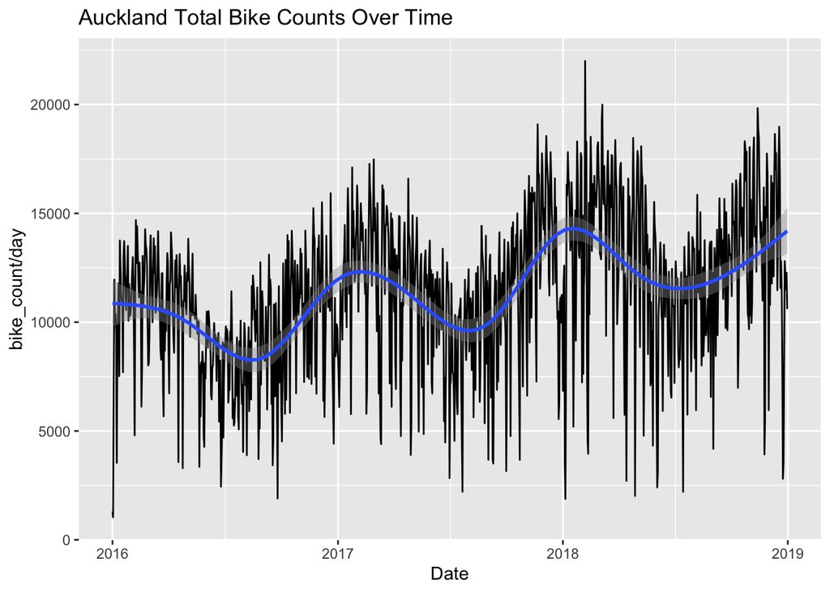

```r
which_season = function(month) {
    if (month %in% c("Dec", "Jan", "Feb")){
        season = "Summer"
    } else if (month %in% c("Mar", "Apr", "May")){
        season = "Fall"
    } else if (month %in% c("Jun", "Jul", "Aug")){
        season = "Winter"
    } else if (month %in% c("Sep", "Oct", "Nov")){
        season = "Spring"
    }
    season
}



bike_rain_day <- bike_rain_day %>%
    mutate(Dow=factor(weekdays(Date, abbreviate=TRUE), c("Mon", "Tue", "Wed", "Thu", "Fri", "Sat", "Sun"))) %>%
    mutate(Season=factor(map(months(bike_rain_day$Date, abbreviate = TRUE), which_season), c("Summer", "Fall", "Winter", "Spring")))

# Plot
bike_rain_day %>% ggplot(aes(x=Date, y=`bike_count/day`)) + geom_line() + geom_smooth() + labs(title = 'Auckland Total Bike Counts Over Time')
```

There is a clear seasonal effect on the bike counts. As seen from the curves of the blue smooth line, bike counts decrease as winter gets closer (around Jun/Jul), then increases as summer approaches (Dec/Jan).

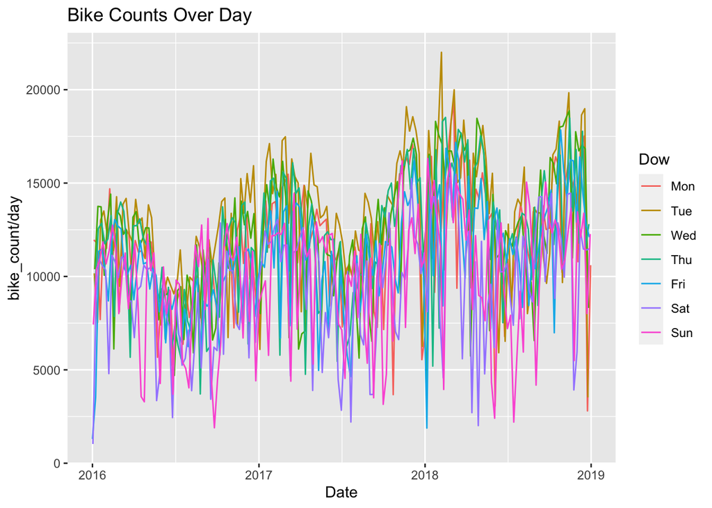

```r
bike_rain_day <- bike_rain_day %>%
    mutate(Year=format(Date, "%Y"))
# Over dow
bike_rain_day %>% ggplot(aes(x=Date, y=`bike_count/day`, col=Dow)) + geom_line() + labs(title = 'Bike Counts Over Day')
```

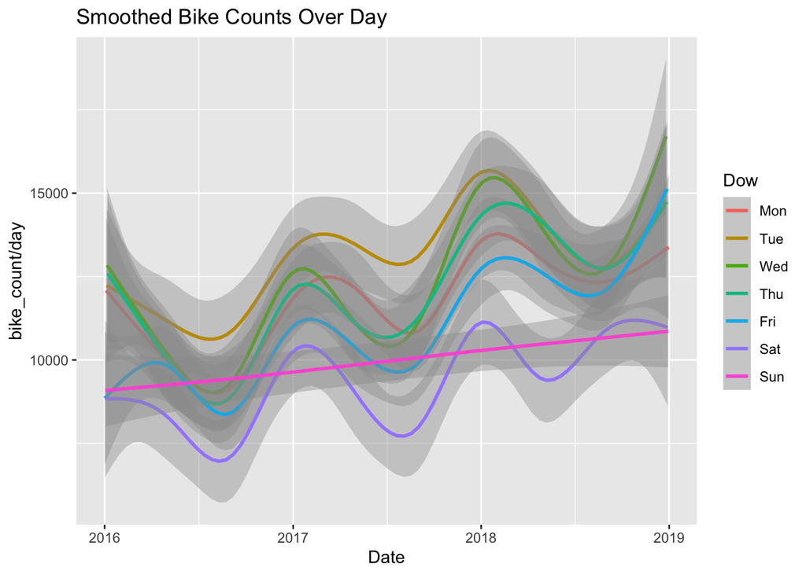

```r
bike_rain_day %>% ggplot(aes(x=Date, y=`bike_count/day`, col=Dow)) + geom_smooth(method="gam") + labs(title = 'Smoothed Bike Counts Over Day')
```

There seems to be a sign of two clumpings of weekdays and weekends, but it is not strong. It could be argued that in general there were less bikes counted in the weekends, especially near the end of the dataset.

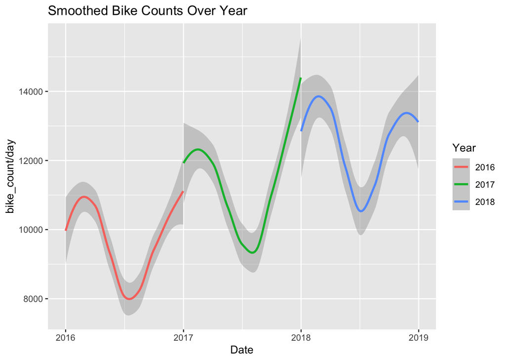

```r
bike_rain_day %>% ggplot(aes(x=Date, y=`bike_count/day`, col=Year))+ labs(title = 'Smoothed Bike Counts Over Year') + geom_smooth()
```

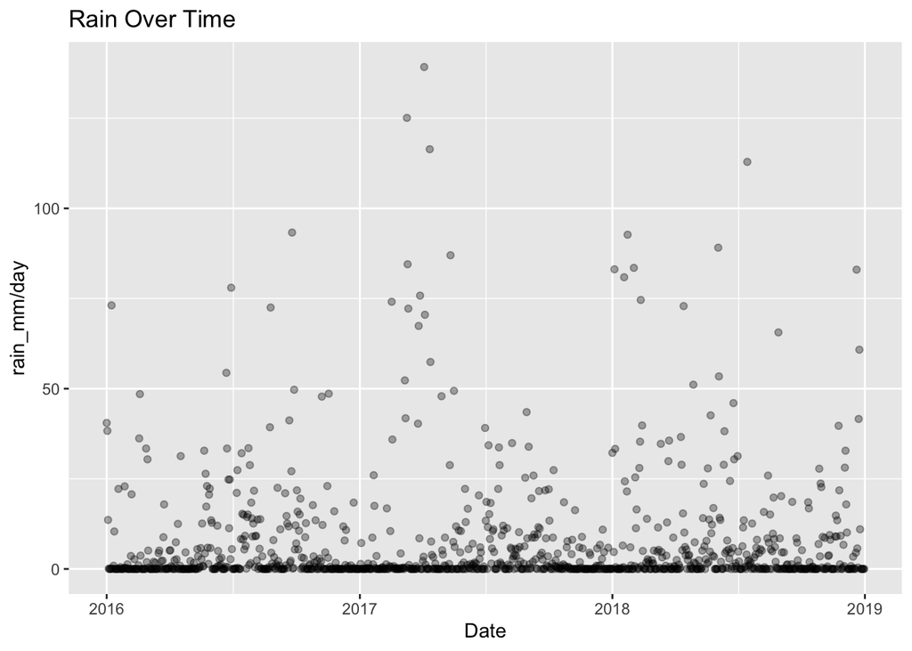

```r
bike_rain_day %>% ggplot(aes(x=Date, y=`rain_mm/day`)) + geom_point(alpha = 0.33) + labs(title = "Rain Over Time")
```

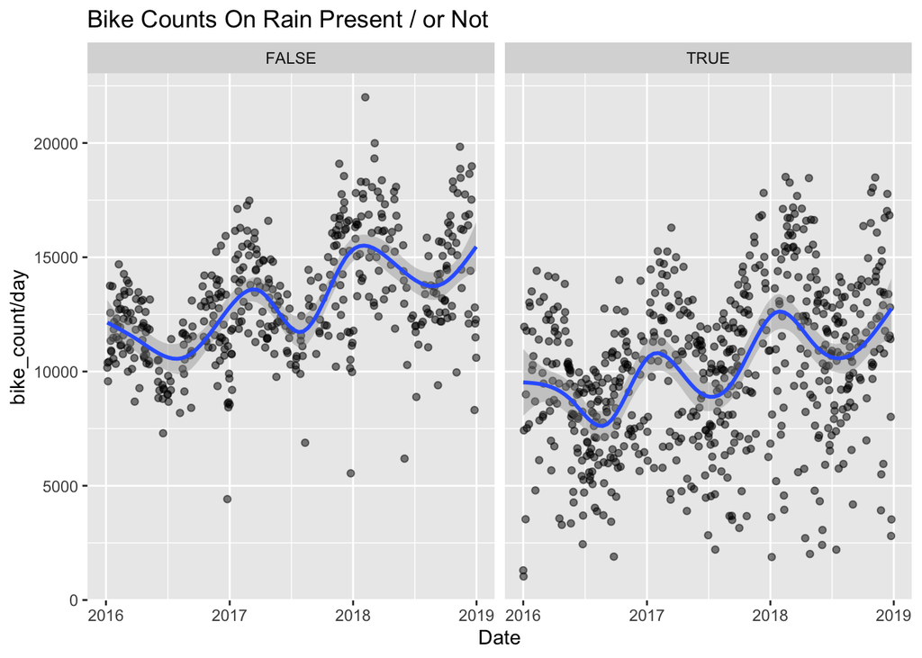

```r
bike_rain_day <- bike_rain_day %>%
    mutate(Rain_Present=`rain_mm/day`>0)

bike_rain_day %>% ggplot(aes(x=Date, y=`bike_count/day`)) + geom_point(alpha = 0.5) + facet_wrap(~Rain_Present) + geom_smooth(method = "gam") + labs(title = "Bike Counts On Rain Present / or Not")
```

It seems clear that, in general, there are less bikes observed when there's any rain present. It's also reasonable to assume quadratic effect on the `rain_mm/day` because people may still choose to ride bikes when there's small amount of rain present, but certainly not when there's heavy rain.

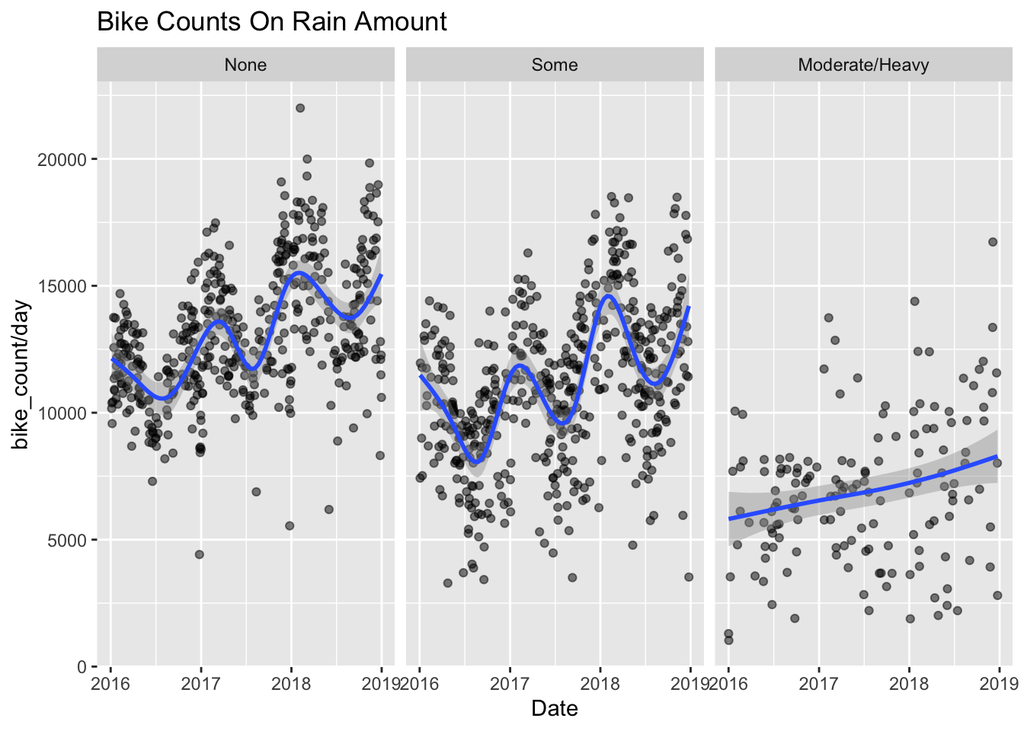

```r
rain_amount = function(rain) {
    if (rain == 0){
        amount = "None"
    } else if (rain > 0 & rain <= 15){
        amount = "Some"
    } else{
        amount = "Moderate/Heavy"
    }
    amount
}

bike_rain_day <- bike_rain_day %>%
    mutate(Rain_Amount=factor(map(bike_rain_day$`rain_mm/day`, rain_amount), c("None", "Some", "Moderate/Heavy")))

bike_rain_day %>% ggplot(aes(x=Date, y=`bike_count/day`)) + geom_point(alpha = 0.5) + facet_wrap(~Rain_Amount) + geom_smooth(method = "gam") + labs(title = "Bike Counts On Rain Amount")
```

The number of bike counts goes down a lot when there's moderate/heavy rain (>15mm/day) present. Quadratic effect of `rain_mm/day` seems to be present.

# 4. Fit a regression model to predict the number of cyclists from year, season, day of the week, and rain.

We can tell from the previous question that variables (`Dow`, `Season`, `rain_mm/day`, `rain_mm/day^2`, `Year`, `Rain_Present`) all have significant effect on the number of bikes counted in Auckland.

```r
bike_reg = lm(`bike_count/day` ~ Dow + Season + poly(`rain_mm/day`, 2, raw = TRUE) + Year + Rain_Present, data=bike_rain_day)

summary(bike_reg)
```

```
##
## Call:
## lm(formula = `bike_count/day` ~ Dow + Season + poly(`rain_mm/day`,
##     2, raw = TRUE) + Year + Rain_Present, data = bike_rain_day)
##
## Residuals:
##      Min       1Q   Median       3Q      Max
## -10050.4  -1051.0     73.2   1067.6   6075.4
##
## Coefficients:
##                                       Estimate Std. Error t value Pr(>|t|)
## (Intercept)                         12423.0903   204.5008  60.748  < 2e-16 ***
## DowTue                               1327.7359   214.3296   6.195 8.28e-10 ***
## DowWed                               1022.9071   214.7008   4.764 2.15e-06 ***
## DowThu                                503.9875   214.3914   2.351 0.018913 *
## DowFri                               -737.1884   214.0269  -3.444 0.000594 ***
## DowSat                              -2154.9526   213.9300 -10.073  < 2e-16 ***
## DowSun                              -1637.0410   213.9894  -7.650 4.43e-14 ***
## SeasonFall                           -164.2458   162.7847  -1.009 0.313212
## SeasonWinter                        -2158.3683   164.6048 -13.112  < 2e-16 ***
## SeasonSpring                         -380.5955   163.5588  -2.327 0.020151 *
## poly(`rain_mm/day`, 2, raw = TRUE)1  -197.8224     9.4022 -21.040  < 2e-16 ***
## poly(`rain_mm/day`, 2, raw = TRUE)2     1.2957     0.1065  12.168  < 2e-16 ***
## Year2017                             1589.3253   140.5061  11.311  < 2e-16 ***
## Year2018                             3093.6089   140.3238  22.046  < 2e-16 ***
## Rain_PresentTRUE                    -1247.7263   135.9873  -9.175  < 2e-16 ***
## ---
## Signif. codes:  0 '***' 0.001 '**' 0.01 '*' 0.05 '.' 0.1 ' ' 1
##
## Residual standard error: 1895 on 1081 degrees of freedom
## Multiple R-squared:  0.7041, Adjusted R-squared:  0.7003
## F-statistic: 183.7 on 14 and 1081 DF,  p-value: < 2.2e-16
```

```r
anova(bike_reg)
```

```
## Analysis of Variance Table
##
## Response: bike_count/day
##                                      Df     Sum Sq    Mean Sq F value    Pr(>F)
## Dow                                   6 1642764505  273794084  76.280 < 2.2e-16
## Season                                3 1310641081  436880360 121.716 < 2.2e-16
## poly(`rain_mm/day`, 2, raw = TRUE)    2 4262436051 2131218025 593.764 < 2.2e-16
## Year                                  2 1715381777  857690889 238.955 < 2.2e-16
## Rain_Present                          1  302173508  302173508  84.186 < 2.2e-16
## Residuals                          1081 3880072068    3589336
##
## Dow                                ***
## Season                             ***
## poly(`rain_mm/day`, 2, raw = TRUE) ***
## Year                               ***
## Rain_Present                       ***
## Residuals
## ---
## Signif. codes:  0 '***' 0.001 '**' 0.01 '*' 0.05 '.' 0.1 ' ' 1
```

# 5. Based on your graphs and model, does rain have a big impact on the number of people cycling in Auckland?

```r
bike_reg_no_poly = lm(`bike_count/day` ~ Dow + Season + `rain_mm/day` + Year + Rain_Present, data=bike_rain_day)

cat("R-Squared with Polynomial Term:", summary(bike_reg)$r.squared, "\n")
```

```
## R-Squared with Polynomial Term: 0.7041155
```

```r
cat("R-Squared without Polynomial Term:", summary(bike_reg_no_poly)$r.squared)
```

```
## R-Squared without Polynomial Term: 0.6635896
```